# AZ Bison IPM Development

Josh Nowak & Paul Lukacs

March 2017

## Summary

This document summarizes model development and background work that went into developing an integrated population model (IPM) for bison in Arizona unit 12A. The model combines what is known of bison ecology with harvest data and aerial surveys of the bison population. Because data on vital rates are largely absentthe models rely on previously published worked and synopses of well studied bison populations.

## Background

A non-exhaustive review of published literature revealed surprisingly consistent estiamtes of vital rates. These values were used as prior information in the model. Prior information, in the context of a Bayesian analysis, is simply a best guess prior to confronting a model with data.

### Reproduction

In most studies bison were said to give birth to a single calf in late April and May. Birthing was sometimes reported to be extremely punctuated with cows having the ability to adjust the timing of birth when their body condition allowed. The gestation period for bison was routinely reported as 285 days, but some reports loosely reported 9 to 9.5 months. The peak of the rut is generally thought to occur around August 1 of each year. Little was said about latitudinal variation in these rates. Cow bison give birth for the first time at two years of age, but pregnancy rates are generally low relative to other game species. On the National Bison Range in Moiese, MT cow bison at least 2 years of age exhibited pregnancy rates between 0.63 and 0.71 from 2008 to 2010. In Yellowstone National Park animals > 1 year old had an overall pregnancy rate of 0.65 with markedly different rates in alternate ages for animals between 3 and 7 years old. The alternating rates anecdotally suggest cows may give birth every other year. While several studies reported declines in reproductive output after 7-10 years of age the data available for this study is too sparse to allow incorporating this decline. Given the reported numbers in the literatue we chose to describe reproduction as a binomial process with a mean probability of success of 0.34 (SD = 0.08). This prior suggests that on average 34/100 of the adult cow population gives birth to a single calf that is then recruited into the adult population the following spring. Initially we assumed the sex ratio of offspring to be equal. The reproduction prior distrbution is shown below. Note the spread of the distribution, which allows for a variety of values to be evaluated.

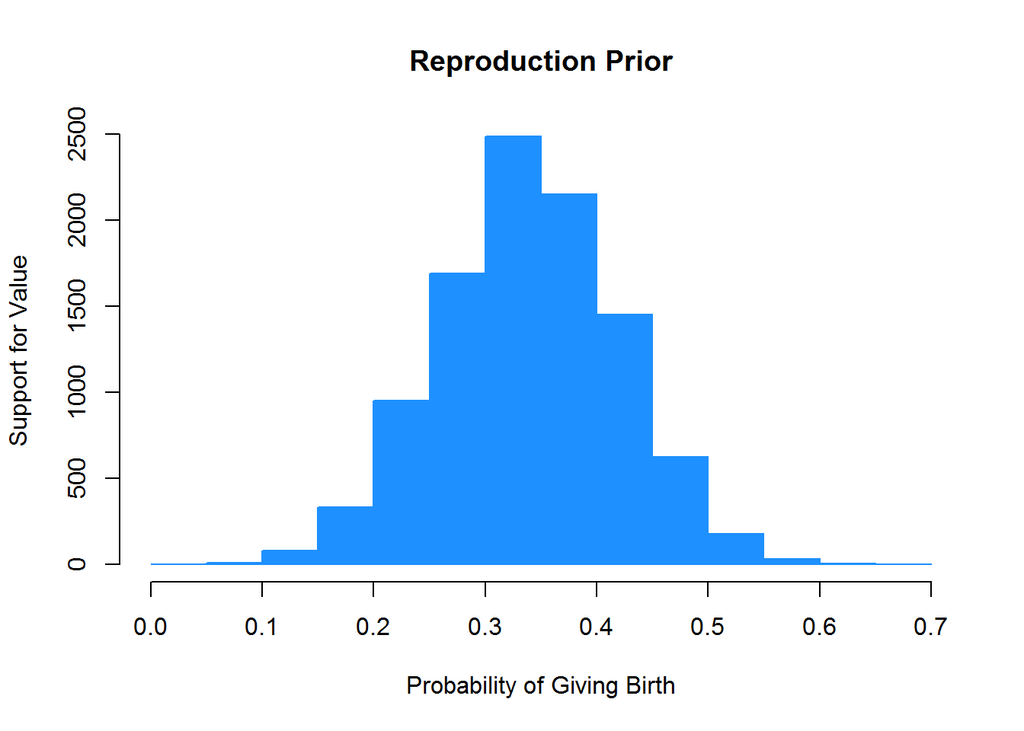

The reproductive process can be described by:

```r
N_calves[yr] = N_adult_females[yr] * R
```

where R is the recruitment parameter with a prior distribution centered at 0.34.

The use of a ratio in this manner subsumes several biological processes. In reality a female must first become pregnant, then she must survive until the time of birth, give birth and then cow and calf must survive until the calf is weaned and then the calf must survive to be counted. However, in practice we have found the approximation above a reasonable assumption and give credit to Lubow and White (2002) for the original idea.

### Survival

Bison survival is generally reported to be extremely high, but it should be noted that few estimates were found from heavily hunted populations. For example, calf bison in YNP survived with probability 0.75 (SD = 0.06) in the first month of life and 0.87 (SD = 0.05) for the remainder of the first year. Adult female bison survival ranged from 0.91 to 0.96 in the presence of the suite of predators in the Greater YNP ecosystem. It was also noted that male life expectancy was roughly half that of females. Because we were looking to build population reconstruction into the model we also needed estimates of harvest mortality rate and other mortality rate where other refers to all causes of death that are not harvest. We began by noting that `mortality + survival = 1`. As mentioned we split mortality into harvest and other, so our equation becomes `harv_mort + other_mort + survival = 1`. To put numbers to the math, assume that adult female survival has a mean of 0.85. That means that the sum of all mortality sources must equal `1 - 0.85` or `0.15`. If we further assume that harvest mortality rate is about `0.1` then we can solve the remaining term (i.e. other_mort) by `1 - 0.85 - 0.10 = 0.05`. This relationship among the two sources of mortality and survival is critical to understanding the reconstruction portion of the model.

Given the information above we created the following prior distributions for adult females:

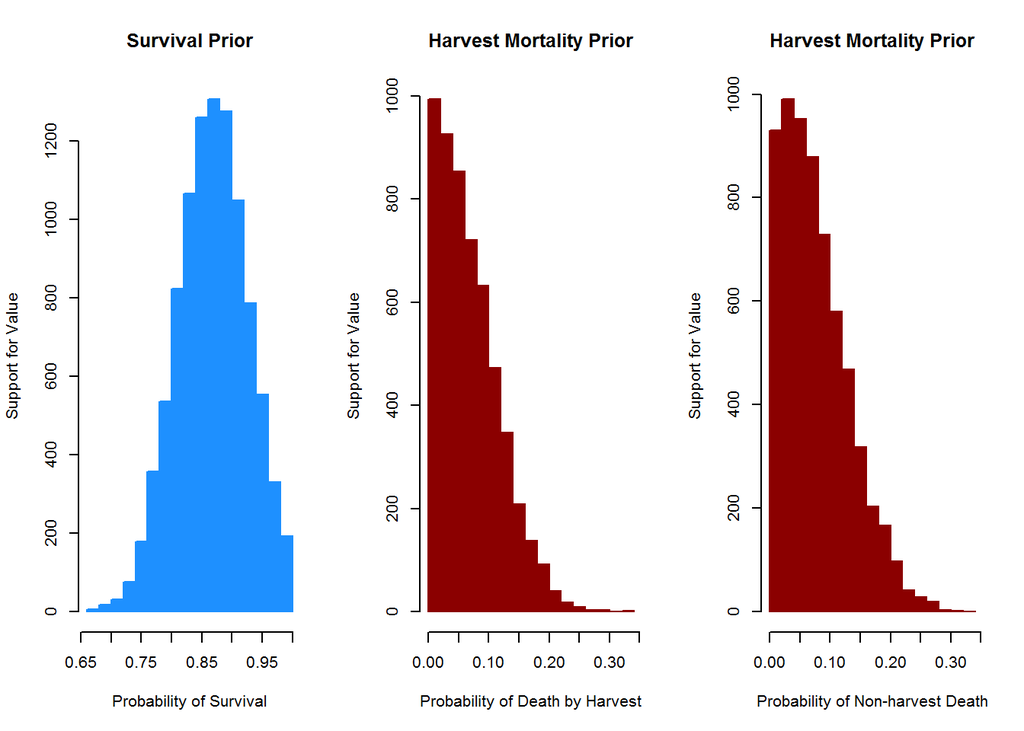

The full table of survival priors is as follows

|  | Species | Parameter | Age | Sex | Mean | SE |
| --- | --- | --- | --- | --- | --- | --- |
| 1 | Bison | Survival | Juvenile | M | 0.85 | 0.06 |
| 2 | Bison | OtherMort | Juvenile | M | 0.05 | 0.06 |
| 3 | Bison | HarvMort | Juvenile | M | 0.1 | 0.06 |
| 4 | Bison | Survival | Adult | M | 0.85 | 0.06 |
| 5 | Bison | OtherMort | Adult | M | 0.03 | 0.06 |
| 6 | Bison | HarvMort | Adult | M | 0.12 | 0.06 |
| 7 | Bison | Survival | Juvenile | F | 0.85 | 0.06 |
| 8 | Bison | OtherMort | Juvenile | F | 0.05 | 0.06 |
| 9 | Bison | HarvMort | Juvenile | F | 0.1 | 0.06 |
| 10 | Bison | Survival | Adult | F | 0.87 | 0.06 |

[output cut: 3 more lines]

The priors are adjustable and should be adjusted to evaluate the effect of the assumed values. A spreadsheet containing all the priors can be downloaded from [this link](https://github.com/Huh/PopR_AZGF).

With priors assigned to the values of survival we can proceed to the biological description of how animals transition from one time step to the next and from one age class to the next. A matrix population model is used to describe this process. Beginning with calves, we can describe the transition of calves to juveniles as

```r
N_juv[yr] = N_calf[yr-1] * juv_surv[yr-1] - N_harvested[yr-1]
```

The process of juveniles transitioning to the adult age class is the same except that adults can remain within the adult age class if they survive.

```r
N_adult[yr] = (N_juv[yr-1] + N_adult[yr-1]) * adult_surv[yr-1] - N_harvested[yr-1]
```

### Incorporating Data

While the description above represents the basic biology of the population and some of what is known about bison populations we also desire to include data collected in the field. For this study data comes primarily in two forms 1) aerial surveys and 2) harvest. The aerial surveys are thought to be indices of the actual population size because they do not account for imperfect detection or animal movement, but are useful as a minimum number of animals present each year. The harvest estimates on the other hand can be considered robust estimates of how many animals of each age and sex class were harvested each year.

#### Population Reconstruction

The basic equation used to reconstruct a population relies on a simple relationship between the size of the population and the number of animals harvested. `N_harvest = N_total * harvest_rate` If we use a bit of algebra to solve for the population size, `N_total`, we get the following equation `N_total = N_harvest/harvest_rate` We can exploit this equation to derive estimates of population size. For example, if 100 animals were harvested and the harvest rate were 0.1 then `100/0.1 = 1000` animals in the population. To make our example more concrete consider that a total of 50 bison were reportedly harvested in 2015. If we assume our same harvest rate of 0.1 then an estimate of the population size is 500 bison. A range of harvest rates and the resulting population sizes are shown in the table below

|  | Year | Harvest | HarvRate | N |
| --- | --- | --- | --- | --- |
| 1 | 2015 | 50 | 0.1 | 500 |
| 2 | 2015 | 50 | 0.2 | 250 |
| 3 | 2015 | 50 | 0.3 | 167 |
| 4 | 2015 | 50 | 0.4 | 125 |
| 5 | 2015 | 50 | 0.5 | 100 |
| 6 | 2015 | 50 | 0.6 | 83 |
| 7 | 2015 | 50 | 0.7 | 71 |
| 8 | 2015 | 50 | 0.8 | 62 |
| 9 | 2015 | 50 | 0.9 | 56 |
| 10 | 2015 | 50 | 1 | 50 |

But what value of harvest rate should we choose? The answer is we should let the model tell us which value is most likely. By combining prior information about survival, reproduction and the matrix model describing how bison populations grow only a certain range of values are possible. Then too, the time-series itself provides information about the range of values that are likely and how large the population needs to be to allow for harvest to be sustained.

For a more technical treatment of this topic consider reading Paul Conn’s dissertation [linked here](http://users.jyu.fi/~hemipu/itms/conn%20phd%20thesis.pdf).

#### Aerial Surveys

Because the aerial surveys do not produce estimates of abundance we assign a binomial distribution to the counts and adjust the counts according to some mean value. The model considers the number of trials to be equal to the number of animals in a given age and sex class output by the matrix model. The probability of a success is a latent quantity to be estimated and the observed number of success is the count data.

`N_observed[year, age, sex] ~ binomial(p, N[year, age, sex])`

### Initial Results

The initial results are contained within a separate document and not shared publicly.

### Further Explanations, Comments, Questions

We use the tools available at GitHub to track changes in our code, document work and facilitate forum like discussions. Please visit the public repository at [this link](https://github.com/Huh/PopR_AZGF) if interested in participating. You may be asked to create an account before the full suite of tools becomes available to you.

*No data will ever be hosted on the public repository associated with any state’s project.*

If you would rather email that information is provided below, but be aware that the progress of project enhancements, bug fixes and other requests will be tracked on GitHub. We need to use this tool to keep track of all the changes and make sure that your needs are being met.

Josh Nowak josh.nowak@speedgoat.io

Paul Lukacs paul.lukacs@speedgoat.io